# R Notebook

ОМ-3, Бабієнка Іллі

Включаємо усі необхідні бібліотеки

```r
library(psych)
library(countreg)
library(corrplot)
library(qgraph)
library(TTR)
library(forecast)
library(ggplot2)
```

ЛАБОРАТНОРНА 1

Зчитуємо дані (датасет - статистика онлайн кусрів з платформи edX від Гарварду та МІТа, опис у ворд-файлі)

```r
data <- read.csv("C:/Users/Admin/Desktop/DatAn/edX_course_stats.csv")
attach(data)
```

[output not shown]

[output cut: 20 more lines]

[output not shown]

Формуємо нашу вибірку - середній вік осіб, що проходили даний курс.

```r
X <- Median.Age
X_nmw <- X[!is.na(X)]
```

Мода

```r
getmoda <- function(v) {
   uniqv <- unique(v)
   uniqv[which.max(tabulate(match(v, uniqv)))]
}
moda <- getmoda(X_nmw)
moda
```

```
[1] 27
```

Медіана

```r
median <- median(X, na.rm = TRUE)
median
```

```
[1] 29
```

Мат-сподівання

```r
mean <- mean(X, na.rm = TRUE)
mean
```

```
[1] 29.3
```

Середнє гармонічне

```r
harmonic.mean <- harmonic.mean(X, na.rm = TRUE)
harmonic.mean
```

```
[1] 28.80462
```

Дисперсія

```r
var <- var(X, na.rm = TRUE)
var
```

```
[1] 16.38547
```

Стандартне (середньоквадратичне) відхилення

```r
sd <- sd(X, na.rm = TRUE)
sd
```

```
[1] 4.047897
```

Інтерквартильна широта

```r
IQR <- IQR(X, na.rm = TRUE)
IQR
```

```
[1] 5
```

Розмах варіації

```r
range <- range(X_nmw)
range
```

```
[1] 22 53
```

Графіки (зображення вибірки)

- Ящик з вусами

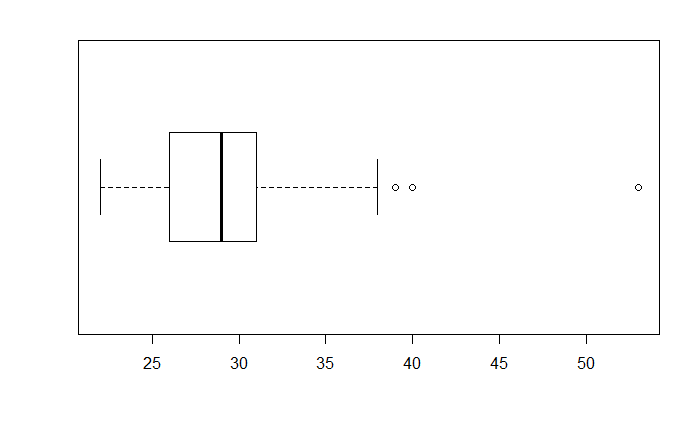

```r
boxplot(X, horizontal = TRUE)
```

- Гістограма

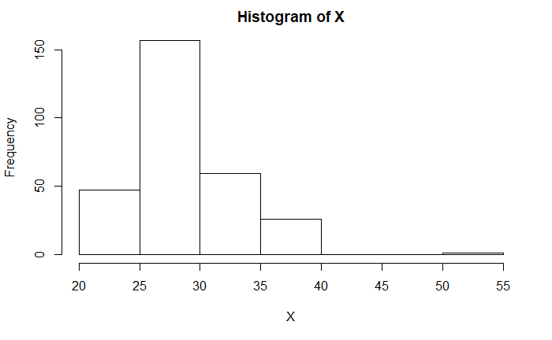

```r
hist(X)
```

- Р-Р plot

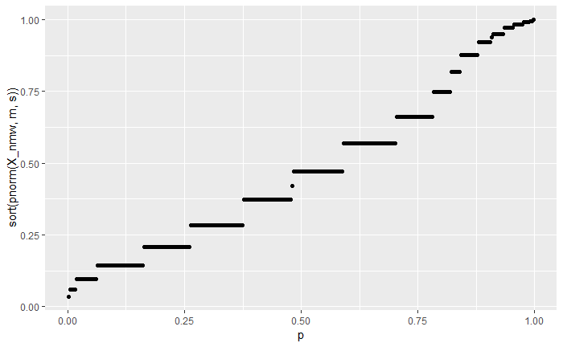

```r
m <- mean(X_nmw)
s <- sd(X_nmw)
n <- length(X_nmw)
p <- (1 : n) / n - 0.5 / n
ggplot(data.frame(X_nmw), main="P-P-plot") + geom_point(aes(x = p, y = sort(pnorm(X_nmw, m, s))))
```

- Q-Q plot

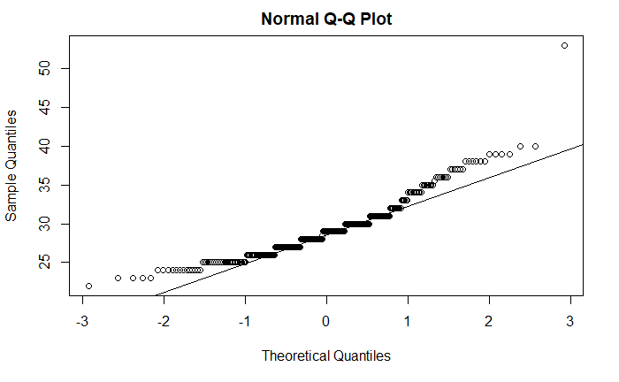

```r
qqnorm(X)
qqline(X)
```

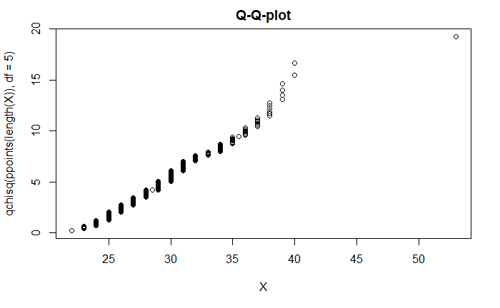

```r
qqplot(X, qchisq(ppoints(length(X)), df = 5),  main="Q-Q-plot")
```

Перевірка на нормальність

```r
normal <- shapiro.test(X_nmw)
normal
```

```
    Shapiro-Wilk normality test

data:  X_nmw
W = 0.91536, p-value = 9.895e-12
```

ЛАБОРАТОРНА 2

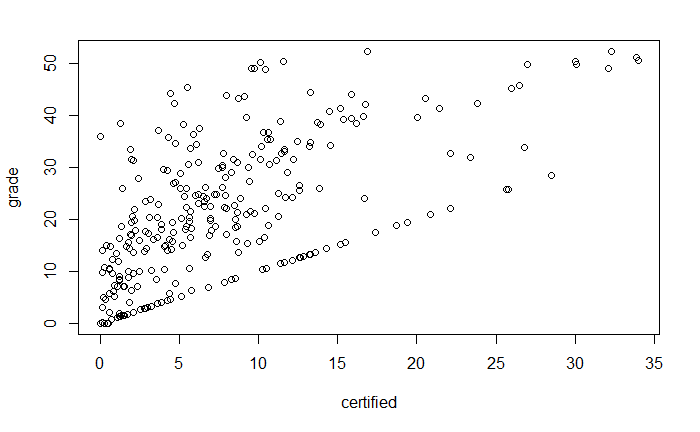

```r
hours <- Total.Course.Hours..Thousands.
forum_posts <- X..Posted.in.Forum
bachelors <- X..Bachelor.s.Degree.or.Higher
certified <- X..Certified
grade <- X..Grade.Higher.Than.Zero
cor <- cor(data.frame(hours, forum_posts, bachelors, certified, grade), use = "complete.obs")
plot(certified, grade)
```

Кореляційна карта

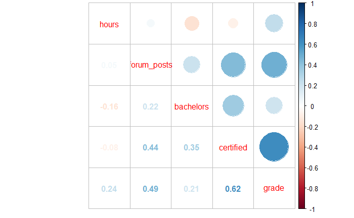

```r
corrplot.mixed(cor)
```

Граф кореляцій

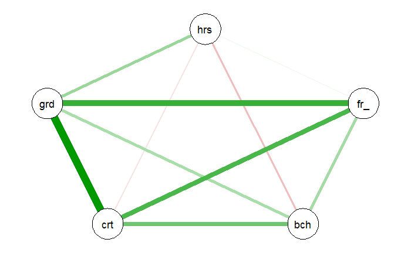

```r
qgraph(cor) # layout = "spring"
```

Матриця кореляцій

```r
cor
```

```
                  hours forum_posts  bachelors   certified     grade
hours        1.00000000  0.04683174 -0.1559142 -0.07617954 0.2428034
forum_posts  0.04683174  1.00000000  0.2166792  0.43974664 0.4886114
bachelors   -0.15591422  0.21667922  1.0000000  0.35097362 0.2094706
certified   -0.07617954  0.43974664  0.3509736  1.00000000 0.6212305
grade        0.24280340  0.48861144  0.2094706  0.62123055 1.0000000
```

Коефіцієнти кореляції (для залежності між відсотком осіб що завершили курс та оцінкою ми обрали саме ці дві величини, адже з результатів вище можна припустити, що між ними залежність сильніша ніж між іншими парами величин)

- Пірсона

```r
cor(certified, grade, use = "complete.obs", method = "pearson")
```

```
[1] 0.6212305
```

- Кендала

```r
cor(certified, grade, use = "complete.obs", method = "kendall")
```

```
[1] 0.4684575
```

- Спірмена

```r
cor(certified, grade, use = "complete.obs", method = "spearman")
```

```
[1] 0.6382382
```

ЛАБОРАТОРНА 3

Лінійна регресія

Датасет - статистика посадок літаків з аеропорту Сан-Франциско за 2015 рік. Досліджуватимемо залежність між к-стю посадок та загальною перевезеною вагою

```r
data <- read.csv("C:/Users/Admin/Desktop/DatAn/air-traffic-landings-statistics.csv")
attach(data)
```

[output not shown]

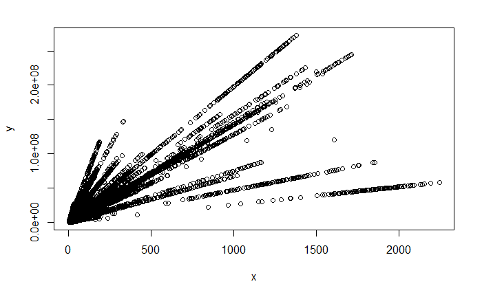

```r
x <- Landing.Count
y <- Total.Landed.Weight
plot(x,y)
```

На графіку гарно розрізняються кілька залежностей - оскільки різні види літаків мають різну середню вантажопідйомність.

```r
z <- lm(x~y)
residuals <- z$residuals
summary(z)
```

```
Call:
lm(formula = x ~ y)

Residuals:
    Min      1Q  Median      3Q     Max
-611.48  -44.35    7.00   14.39 1880.16

Coefficients:
              Estimate Std. Error t value Pr(>|t|)
(Intercept) -8.964e+00  1.241e+00  -7.221 5.34e-13 ***
y            6.454e-06  3.496e-08 184.593  < 2e-16 ***
---
Signif. codes:  0 ‘***’ 0.001 ‘**’ 0.01 ‘*’ 0.05 ‘.’ 0.1 ‘ ’ 1

Residual standard error: 155.3 on 21844 degrees of freedom
Multiple R-squared:  0.6094,    Adjusted R-squared:  0.6093
F-statistic: 3.407e+04 on 1 and 21844 DF,  p-value: < 2.2e-16
```

Q-Q-графіік для модельних залишків

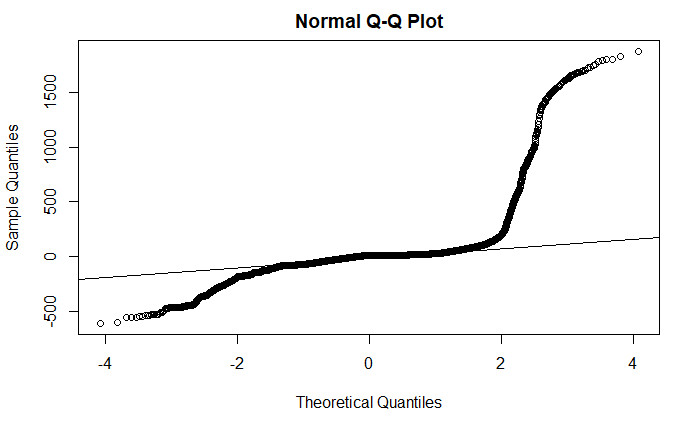

```r
qqnorm(residuals)
qqline(residuals)
```

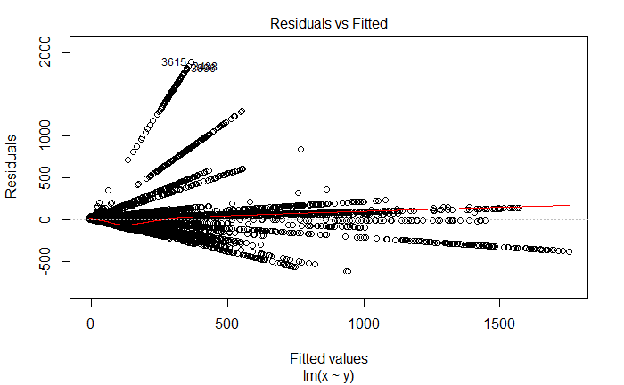

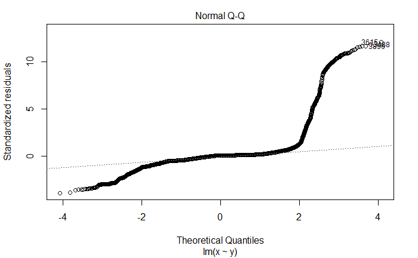

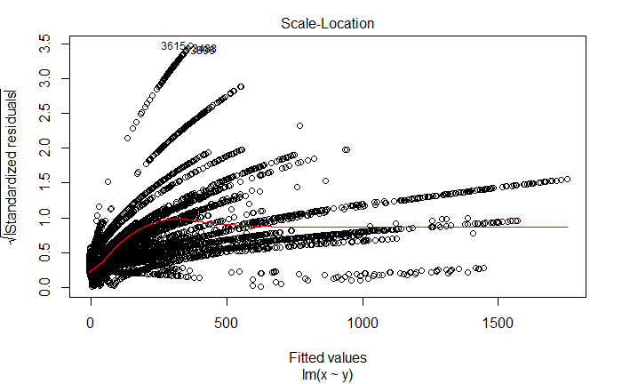

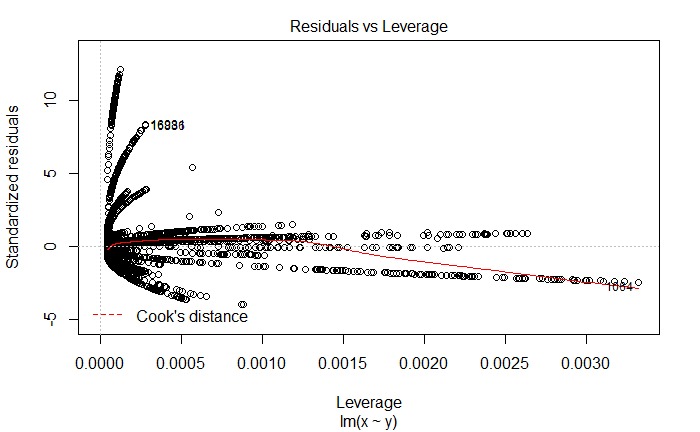

```r
plot(z)
```

Гістограма залишків

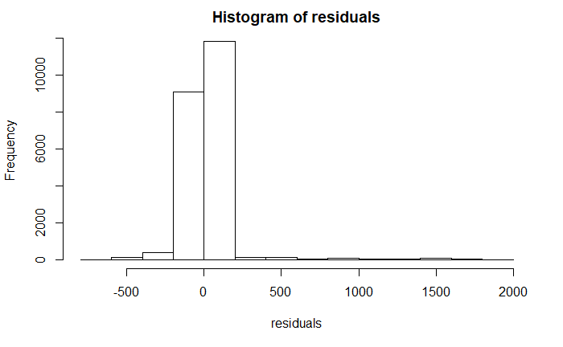

```r
hist(residuals)
```

ЛАБОРАТОРНА 4

```r
data <- read.csv("C:/Users/Admin/Desktop/DatAn/edX_course_stats.csv")
colnames(data) <- c("Institution",
"Course Number",
"Launch Date",
"Course Title",
"Instructors",
"Course Subject",
"Year",
"Honor Code Certificates",
"Participants (Course Content Accessed)",
"Audited > 50%",
"Certified",
"% Audited",
"% Certified",
"% Certified of > 50% Course Content Accessed",
"% Played Video",
"% Posted in Forum",
"% Grade Higher Than Zero",
"Total Course Hours (Thousands)",
"Median Hours for Certification",
"Median Age",
"% Male",
"% Female",
"% Bachelor\'s Degree or Higher")
attach(data)
```

[output not shown]

```r
our_data <- data[,c("Course Subject","% Certified")]
```

Зобразимо графік (боксплот), щоб попередьно оцінити наявність залежності (схожостей/відмінностей) в розподілах данних для різних категорій.

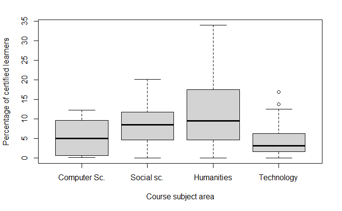

```r
our_data$`Course Subject` = factor(our_data$`Course Subject`,labels = c("Computer Sc.", "Social sc.", "Humanities", "Technology"))
#ggplot(our_data, aes(x = `Course Subject`, y = `% Certified`))
boxplot(our_data$`% Certified`~our_data$`Course Subject`,data=`Course Subject`,col="light gray",xlab="Course subject area",ylab="Percentage of certified learners")
```

Створюємо модель, за допомогою якої будемо досліджувати залежність між данними.

```r
mod <- lm(our_data$`% Certified`~our_data$`Course Subject`,data = our_data)
summary(mod)
```

```
Call:
lm(formula = our_data$`% Certified` ~ our_data$`Course Subject`,
    data = our_data)

Residuals:
    Min      1Q  Median      3Q     Max
-11.712  -3.913  -1.032   3.304  22.268

Coefficients:
                                    Estimate Std. Error t value Pr(>|t|)
(Intercept)                            5.199      1.140   4.561 7.55e-06 ***
our_data$`Course Subject`Social sc.    3.144      1.349   2.331   0.0204 *
our_data$`Course Subject`Humanities    6.513      1.309   4.975 1.13e-06 ***
our_data$`Course Subject`Technology   -1.087      1.314  -0.827   0.4090
---
Signif. codes:  0 ‘***’ 0.001 ‘**’ 0.01 ‘*’ 0.05 ‘.’ 0.1 ‘ ’ 1

Residual standard error: 6.243 on 286 degrees of freedom
Multiple R-squared:  0.2065,    Adjusted R-squared:  0.1982
F-statistic: 24.81 on 3 and 286 DF,  p-value: 2.693e-14
```

```r
anova(mod)
```

```
Analysis of Variance Table

Response: our_data$`% Certified`
                           Df  Sum Sq Mean Sq F value    Pr(>F)
our_data$`Course Subject`   3  2901.1  967.05  24.808 2.693e-14 ***
Residuals                 286 11148.5   38.98
---
Signif. codes:  0 ‘***’ 0.001 ‘**’ 0.01 ‘*’ 0.05 ‘.’ 0.1 ‘ ’ 1
```

Бачимо що досягнутий рівень значущості p~10^(-14). Отже при рівні p = 0.05 значущості гіпотезу про рівність середніх відкидаємо.

Отже э зв’язок між предметною сферою та відсотком люедй які повністю пройшли відповідні курси.

Обчилсимо (95%) довірчі інтервали для наших груп (предметів).

```r
confint(mod)
```

```
                                         2.5 %   97.5 %
(Intercept)                          2.9556822 7.442984
our_data$`Course Subject`Social sc.  0.4895428 5.798991
our_data$`Course Subject`Humanities  3.9360793 9.089935
our_data$`Course Subject`Technology -3.6739899 1.500378
```

Модельні залишки можна зобразити відносно підігнаних (оціночних - fitted value) значень, щоб перевірити припущення моделі.

[figure not shown]

```r
mod2 = data.frame(Fitted = fitted(mod), Residuals = resid(mod), Subject = our_data$`Course Subject`)
ggplot(mod2, aes(Fitted, Residuals, colour = subject)) + geom_point()
```

Бачимо що розподіли для різних предметних сфер все ж відрізняються, адже дані по-різному розсіяні.